# Control Structures, Apply & Functions

# Control Structures

- `if` and `else`: testing a condition and acting on it
- `for`: execute a loop a fixed number of times
- `while`: execute a loop *while* a condition is true
- `repeat`: execute an infinite loop (must `break` out of it to stop)
- `break`: break the execution of a loop
- `next`: skip an iteration of a loop

## Control Structures: if-else

```r
if (<condition>) {
  # do something
} else {
  # do something else
}
```

Example:

```r
number <- 15
if (number < 0) {
  print("The number is negative.")
} else {
  print("The number is 0 or positive.")
}
```

```
[1] "The number is 0 or positive."
```

## Comparison and Logical Operators

Comparison operators: `<`, `>`, `<=`, `>=`, `==`, `!=`

```r
10 < 20
```

```
[1] TRUE
```

```r
10 == 10
```

```
[1] TRUE
```

```r
10 != 10
```

```
[1] FALSE
```

Logical operators: AND (`&`), OR (`|`), NOT (`!`)

```r
TRUE & FALSE
```

```
[1] FALSE
```

```r
TRUE | FALSE
```

```
[1] TRUE
```

```r
!TRUE
```

```
[1] FALSE
```

## Control Structures: for loop

For loops are used to iterate over a sequence of values.

```r
for (i in <sequence>) {
  <statements>
}
```

Example:

```r
for (i in 1:5) {
  print(i)
}
```

```
[1] 1
[1] 2
[1] 3
[1] 4
[1] 5
```

## Control Structures: for loop

Using `seq_along()` to iterate over vector indices:

```r
num_vector <- c(2, 4, 6, 8, 10)
squares <- numeric(length(num_vector))
for (i in seq_along(num_vector)) {
  squares[i] <- num_vector[i]^2
}
print(squares)
```

```
[1]   4  16  36  64 100
```

## Nested loops

```r
mat <- matrix(1:6, nrow = 3)
print(mat)
```

```
     [,1] [,2]
[1,]    1    4
[2,]    2    5
[3,]    3    6
```

```r
for (i in seq_len(nrow(mat))) {
  for (j in seq_len(ncol(mat))) {
    cat("Element [", i, ",", j, "] =", mat[i, j], "\n")
  }
}
```

```
Element [ 1 , 1 ] = 1
Element [ 1 , 2 ] = 4
Element [ 2 , 1 ] = 2
Element [ 2 , 2 ] = 5
Element [ 3 , 1 ] = 3
Element [ 3 , 2 ] = 6
```

## Other types of loops

- `while` loops: execute a loop while a condition is true
- `repeat` loops: execute an infinite loop
- `next` skips the current iteration
- `break` exits the loop

```r
while (<condition>) {
  <statements>
}

repeat {
  <statements>
  if (<condition>) break
}
```

## Vectorized operations

- R is optimized for vectorized operations
- Avoid loops when a vectorized solution exists

```r
v <- c(1, 2, 3, 4, 5)
v_squared <- v^2
cat("Vectorized squares:", v_squared, "\n")
```

```
Vectorized squares: 1 4 9 16 25
```

Loop equivalent (less efficient):

```r
v_squared_loop <- numeric(length(v))
for (i in seq_along(v)) {
  v_squared_loop[i] <- v[i]^2
}
cat("Loop computed squares:", v_squared_loop, "\n")
```

```
Loop computed squares: 1 4 9 16 25
```

## Exercise: CpG Island Detection

CpG dinucleotides are depleted in most of the genome (methylation → deamination) but **CpG islands** near gene promoters are protected.

**Task:** Scan a 10,000 bp DNA sequence with a sliding window, count CpG dinucleotides, and plot the result.

## Exercise: Tools you will need

```r
library(stringi)
dna_sequence <- readRDS("../data/dna_sequence.rds")
```

Extract a window with `substr()`:

```r
substr(dna_sequence, 1, 20)
```

```
[1] "AAGACACTCCACCTGAATGC"
```

Count “CG” in a string with `stri_count_fixed()`:

```r
stri_count_fixed("AACGTTCGCG", "CG")
```

```
[1] 3
```

## Exercise: Your task

Everything is set up for you — write the **for loop**:

```r
window_size <- 100
n_windows <- nchar(dna_sequence) - window_size + 1
cpg_counts <- numeric(n_windows)

for (i in 1:n_windows) {
  window <- substr(dna_sequence, ?, ?)
  cpg_counts[i] <- stri_count_fixed(?, ?)
}

plot(cpg_counts, type = "l",
     xlab = "Position (bp)",
     ylab = "CpG count (per 100 bp)",
     main = "CpG Island Detection",
     col = "darkblue")
abline(h = mean(cpg_counts), col = "red", lty = 2)
```

## Apply family of functions

- `apply()`, `lapply()`, `sapply()`, `tapply()`, `mapply()`
- Apply a function to elements of a vector, list, or matrix
- More concise and often faster than explicit loops

```r
apply(<matrix>, <MARGIN>, <function>)  # rows (1) or columns (2)
lapply(<list>, <function>)             # returns list
sapply(<list>, <function>)             # returns vector/matrix
tapply(<vector>, <groups>, <function>) # by group
mapply(<function>, <arg1>, <arg2>)     # multiple arguments
```

## `apply`

- Apply a function to the rows or columns of a matrix
- `MARGIN = 1` for rows, `MARGIN = 2` for columns

```r
set.seed(123)
mat <- matrix(rnorm(20), nrow = 5, ncol = 4)
row_means <- apply(mat, 1, mean)
cat("Row means:", row_means, "\n")
```

```
Row means: 1.041396 0.2721008 -0.3180497 0.04892354 -0.3362517
```

```r
col_means <- apply(mat, 2, mean)
cat("Col means:", col_means, "\n")
```

```
Col means: 0.1935703 -0.04431897 0.3079017 0.1093422
```

## `lapply`

- `lapply` returns a **list** with the result of applying a function to each element

```r
num_list <- list(a = 1:5, b = seq(2, 10, by = 2), c = rnorm(4))
list_means <- lapply(num_list, mean)
print(list_means)
```

```
$a
[1] 3

$b
[1] 6

$c
[1] -0.7601736
```

## `sapply`

`sapply` is a simplified version of `lapply` that returns a vector or matrix.

```r
m <- sapply(num_list, mean)
print(m)
```

```
         a          b          c
 3.0000000  6.0000000 -0.7601736
```

```r
r <- sapply(num_list, range)
print(r)
```

```
     a  b          c
[1,] 1  2 -1.0678237
[2,] 5 10 -0.2179749
```

## `tapply`

- `tapply` applies a function to subsets of a vector defined by a grouping factor

`sample_data` data frame:

| ID | Species | Height | Leaf_Count | Treatment |
| --- | --- | --- | --- | --- |
| 1 | Species_A | 15.2 | 25 | Control |
| 2 | Species_B | 18.5 | 30 | Treatment |
| 3 | Species_A | 14.7 | 22 | Treatment |
| 4 | Species_B | 19.3 | 32 | Control |
| 5 | Species_A | 16.1 | 28 | Control |
| 6 | Species_B | 20.0 | 35 | Treatment |

## `tapply`

Calculate the mean of `Height` for each `Treatment` group:

```r
tapply(sample_data$Height, sample_data$Treatment, mean)
```

[output not shown]

For each level of `Treatment`, `tapply` calculates the mean of `Height`.

## `mapply`

- `mapply` is a multivariate version of `sapply`
- It applies a function to the first elements of each argument, the second elements, and so on.

```r
power_func <- function(x, y) x^y
bases <- c(2, 3, 4, 5)
exponents <- c(3, 2, 2, 1)
mapply(power_func, bases, exponents)
```

```
[1]  8  9 16  5
```

## Apply on expression data

Using `apply` on real expression data:

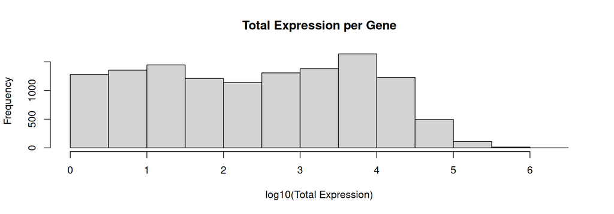

```r
feature_counts <- read.delim("../data/feature_counts.csv")
gene_totals <- apply(feature_counts, 1, sum)
hist(log10(gene_totals),
     main = "Total Expression per Gene",
     xlab = "log10(Total Expression)")
```

## Functions

- Functions are blocks of code that perform a specific task
- Functions take arguments and return a value
- Functions can be built-in, part of a package, or user-defined

```r
my_function <- function(x) {
   # do some stuff with x
   return(some_value)
}
```

## Functions - Example

```r
my_mean <- function(x, na.rm = TRUE) {
  if (!is.numeric(x)) {
    stop("Input must be numeric.")
  }
  result <- mean(x, na.rm = na.rm)
  return(result)
}

test_vector <- c(2, 4, NA, 8, 10)
my_mean(test_vector)
```

```
[1] 6
```

## Functions - Default Arguments

Functions can have default arguments:

```r
normalize_vector <- function(x, na.rm = TRUE) {
  if (na.rm) x <- na.omit(x)
  x_min <- min(x)
  x_max <- max(x)
  return((x - x_min) / (x_max - x_min))
}
normalize_vector(c(5, 10, 15, 20, 25))
```

```
[1] 0.00 0.25 0.50 0.75 1.00
```

## Functions with apply

Combining custom functions with `apply`:

```r
normalize_expression <- function(expr_data) {
  normalized <- t(apply(expr_data, 1, normalize_vector))
  return(normalized)
}
normalized_counts <- normalize_expression(feature_counts)
head(normalized_counts[, 1:4])
```

```
                  NA06985   NA06986    NA06994   NA07000
ENSG00000000003 0.0000000 0.0000000 0.00000000 1.0000000
ENSG00000000005 0.0000000 0.0000000 0.00000000 0.0000000
ENSG00000000419 0.1375000 0.2000000 0.12500000 0.2375000
ENSG00000000457 0.2209302 0.1511628 0.09302326 0.1395349
ENSG00000000460 0.0000000 0.2187500 0.06250000 0.1250000
ENSG00000000938 0.1311475 0.4590164 0.32786885 0.1639344
```

## Functions with apply

```r
heatmap(as.matrix(feature_counts[1:100, 1:10]))
```

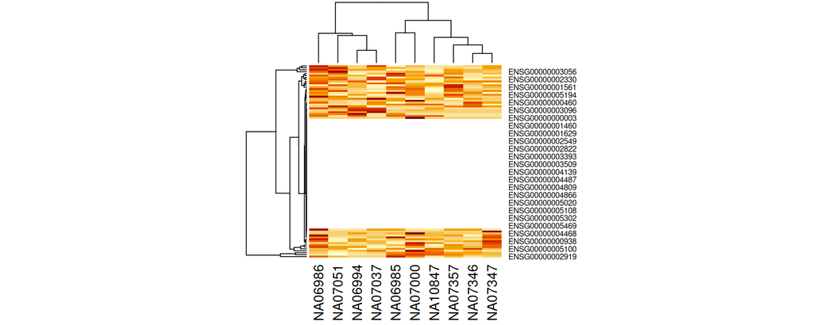

## Differential Expression

```r
feature_annotation <- read.delim(
  "../data/feature_annotation.csv", sep = "\t")

test_de <- function(expr_data, groups) {
  expr_data <- as.matrix(expr_data)
  means <- apply(expr_data, 1,
                 function(x) tapply(x, groups, mean))
  pval <- apply(expr_data, 1,
                function(x) t.test(x ~ groups)$p.value)
  data.frame(t(means), p_value = pval)
}

DE_results <- test_de(feature_counts,
                      feature_annotation$gender)
```

## Differential Expression - Results

```r
library(knitr)
kable(head(DE_results))
```

|  | female | male | p_value |
| --- | --- | --- | --- |
| ENSG00000000003 | 0.1212121 | 0.037037 | 0.2249862 |
| ENSG00000000005 | 0.0303030 | 0.000000 | 0.3248127 |
| ENSG00000000419 | 28.3636364 | 27.296296 | 0.8082585 |
| ENSG00000000457 | 31.3030303 | 39.259259 | 0.1624384 |
| ENSG00000000460 | 7.6060606 | 7.222222 | 0.7958527 |
| ENSG00000000938 | 14.4848485 | 27.000000 | 0.0011892 |

## Volcano Plot

```r
plot(
  log2(DE_results$male / DE_results$female),
  -log10(DE_results$p_value),
  xlab = "log2(fold change)",
  ylab = "-log10(p-value)",
  main = "Volcano Plot",
  col = "#00000060"
)
```

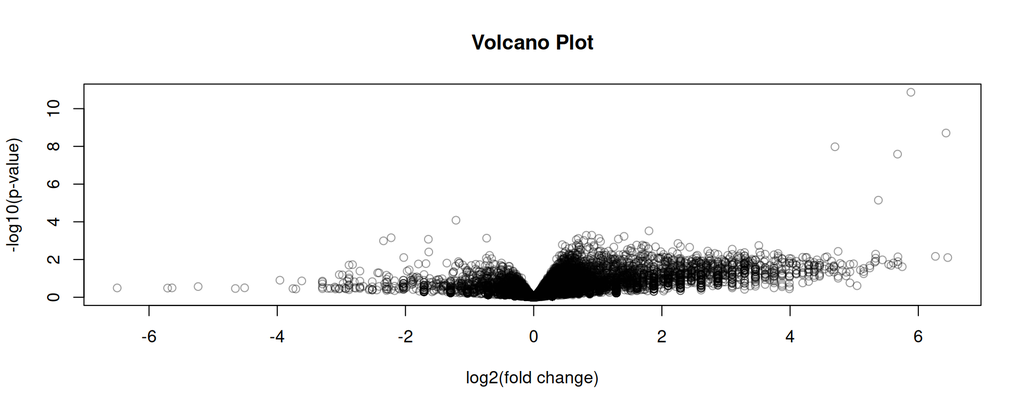